# Dimensions of the impacts of land transitions in the Amazon and Cerrado

Author

Affiliation

Hugo Tameirão Seixas

State University of Campinas

## Introduction

The suppression of native vegetation in the Cerrado and Amazon biomes is a matter of great concern due to its potential impact on the environment and human well-being. Understanding the drivers and effects of this phenomenon is crucial to guide policies to avoid natural vegetation suppression and mitigate negative impacts. However, this is a challenging task since the factors involved in this phenomenon are diverse, heterogeneous, and can even be contradictory. Existing literature suggests that native vegetation suppression is caused by economic fluctuations (Hargrave and Kis-Katos 2012), conservation policies (Pfaff et al. 2015), population distribution (Jusys 2016), land tenure (Cattaneo 2001), livestock and crop productions (Bowman 2016). On the other side, vegetation removal may impact human health (Santos and Almeida 2018), climate regime (Silva, Lopes, and Santos 2023), regional hydrology (Cavalcante et al. 2019), soil properties (Dias et al. 2022), biodiversity (Gestich et al. 2021).

Unfortunately, much of the research in this area tends to focus on only a few dimensions of the problem, rather than taking a holistic approach. This narrow focus often fails to capture the full extent of the issue and can lead to oversimplifications or misdirection in efforts to solve it.

This project aims to predict and understand the causes and impacts of native vegetation suppression in the Cerrado and Amazon biomes, considering environmental and anthropic dimensions. The results will provide a deeper understanding of the relationships between land use changes, environmental factors, and social dynamics related to native vegetation suppression.

Regression and classification models will be applied to existing data on land use changes, environmental factors, and social variables in the Cerrado and Amazon biomes. The models will be used to identify patterns and relationships between these variables and to predict future trends.

The results of this project will contribute to a better understanding of the causes and impacts of native vegetation suppression in the Cerrado and Amazon biomes. This knowledge will inform the development of effective conservation and management strategies that will help to protect these vital and unique ecosystems.

## Objectives

The present work is composed of three main objectives, accompanied by related questions:

1. Predict probability and area of native vegetation suppression in the Amazon and Cerrado;
   1. What are the main drivers of native vegetation suppression?
   2. How do drivers interact among them?
2. Predict land cover transition trajectories after native vegetation suppression;
   1. What are the main drivers of land cover dynamics after native vegetation suppression?
   2. How do drivers interact among them?
   3. What are the main patterns for future projections in the Amazon and Cerrado?
3. Predict the impact of land cover transitions over environmental and social variables;
   1. What is the importance of land cover transitions in predicting environmental and social variables?
   2. Does land-use transitions interact with other drivers of environmental and social variables?
   3. What are the expected social and environmental projections in different land-cover trajectories for the near future?
   4. Do predictions from both biomes show a relation between each other?

The three objectives, in conjunction, will provide an in-depth analysis of how to avoid native vegetation suppression and mitigate its negative impacts.

## Materials and Methods

The study will rely on available data to develop regression and classification models to predict native vegetation suppression and its impacts. To achieve the proposed goal, I will divide the work into four major parts:

1. Literature overview of the main drivers of the expected outcomes (vegetation suppression, land cover transition, social and environmental variables);
2. Screening for available data and development of structured data collection;
3. Development of models;
4. Future projections;

[interactive chart not shown]

The literature review will provide a theoretical and practical basis for the modeling section. Information about the key variables, their manipulation process, and the analysis techniques used to reach the results.

The database structuring will store all the relevant data in a single file structure to facilitate the modeling process.

The modeling process will follow standard procedures and libraries, with the possibility to implement different techniques.

Future projections will serve as a bridge to discuss public policy planning to mitigate the negative impacts of native vegetation suppression in the Amazon and Cerrado.

#### Literature Review

The literature review will address different topics. For all of them, I will adopt a hybrid approach of database searches combined with snowball searches.

[interactive chart not shown]

The literature review will answer questions about variables to be predicted in this project. For each variable, I want to explore the main drivers that cause them, how they relate to each other, and the methods used to estimate the effects and interactions.

#### Database Structuring

The database will contain data from different domains, which can be available in diverse formats and structures. To make the modeling process more efficient and transparent, all variables of interest must be organized coherently. To structure a collection of data that presents different natures, I will transform all the variables into a standard grid system. The grid system will be composed of 0.2 degrees cells (40km x 40km), which should be a balanced compromise between detail and computational cost.

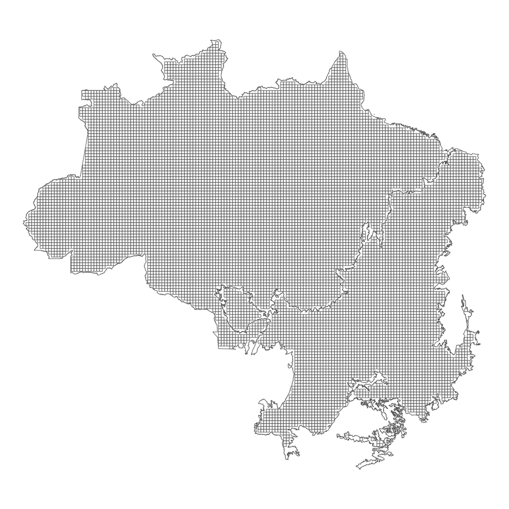

Representation of the spatial grid that will be used to store the data from different sources.

Each grid cell will contain an observation, for each year, for all the variables. Only pixels that contained natural vegetation in the first year of the analysis will be considered valid.

The process to create the database will consist of accessing the data sources, downloading the data to the local environment, transforming and organizing the data to the grid (if the data source provides any pre-processing tool before downloading the data, it should be done that way), and store in the local environment.

[interactive chart not shown]

The data will be stored in a nested directories database with hive-style partitioning. The database will be composed of a collection of parquet files, a format with high compression, that facilitates processing large volumes of data. The main partition will be the variables, which means that each variable will be stored in a separate directory. If necessary, the data will be partitioned by further variables (as a rule of thumb, each parquet file should not be smaller than 20MB and not bigger than 2GB).

#### Model Development

The models will follow a sequential order. The output of a model will serve as a feature of the next model.

| Vegetation suppression probability | Vegetation suppression area | Land cover transitions | Transitions impacts |
| --- | --- | --- | --- |
| Classification | Regression | Classification | Regression |

The first model will classify areas that suffered vegetation suppression. So the outcome will be a binary result (0 = no suppression; 1 = suppression). I want this model to have the minimum inclusion errors for class “1”. In other words, I want to avoid classifying an area with the label “1” when the reality is that it should be labeled “0”. To achieve this, the model will be adjusted to present the minimum inclusion error for class “1”, and the probability threshold to classify an observation as class “1” will be a higher value.

The second model will predict the amount of vegetation suppression that was classified with the label “1” in the previous model. The predictions will have to be bounded by the amount of natural vegetation inside the grid cell (a Poisson distribution may be adequate to represent this variable).

The third model will predict the predominant land use transitions of the areas that suffered native vegetation suppression.

The fourth model will be a set of models. Each model will be responsible to predict a single environmental or social outcome.

Each model will follow the standard approach to develop supervised models.

[interactive chart not shown]

To understand and interpret the predictions made by the models, I will employ a variety of methods. They may include surrogate models, feature interactions, permutation feature importance, counterfactual explanations, and Shapley values. These methods are model-agnostic, meaning they can be applied to any regression or classification model, regardless of its underlying structure or parameters. By using these techniques, I aim to gain a deeper understanding of the relationships between the variables and how they contribute to the predictions. This information will enable assessing the reliability of the models and validity of their results.

## Results

The study will present three main quantitative results based on quantitative data: predictions on vegetation suppression, land use transitions, and social and environmental variables. Our predictions on vegetation suppression will show the likelihood and extent of removal events, serving as a basis for predicting the land use changes of the affected grid cells. Finally, we will predict the impact of these findings on the environment and human well-being.

As part of the study, I will not only present the predictions generated by the models but also perform an in-depth analysis of the model’s behavior. This analysis will provide a deeper understanding of the underlying mechanisms that drive the predictions and help to assess their reliability and accuracy. Furthermore, based on my confidence in the models and their results, I will make inferences about the studied phenomena. This will allow me to go beyond the mere presentation of the predictions and offer insights into the relationships between the variables, the causes of the observed patterns, and the implications of the results for the environment and human well-being. However, it is important to note that I will only take this step if I feel confident in the models and their results, as making inferences requires a strong foundation of knowledge and understanding.

## Discussion

In this study, I will be comparing the outcomes of my models, which are grounded in regression and classification predictive modeling, to the conclusions drawn from previous research that primarily utilized statistical inference and mechanistic models. My aim is to analyze the potential advantages and limitations of the methodology I have developed through this comparison.

In addition to comparing the results of my models with previous research, I will also be exploring the practical implications of the findings. Specifically, I will be examining how the results can be used to inform and support decision making, particularly when dealing with complex environmental and human well-being issues that involve multiple dimensions. In many cases, decision making related to vegetation removals and their impact on the environment and human well-being can be challenging due to the multiple and sometimes conflicting factors that need to be considered.

The findings can be used to identify the most significant factors that contribute to vegetation removals and their impact on the environment and human well-being, as well as how these factors interact with one another. This information can then be used to prioritize the most pressing issues and to design targeted interventions and strategies to mitigate the negative effects of vegetation removals.

## Conclusions

The final outcome of this project is expected to provide answers to the following questions as concluding remarks:

- How suitable were the models to represent the studied phenomena?

The final remarks should summarize the potential of utilizing observed data and statistical models to estimate the causes and impacts of deforestation, as also explore the limitations of this method.

- What are the implications of the results to the development of public policies in the Amazon and Cerrado biomes?

Assuming that the models were suitable for representing the phenomena, the concluding remarks will summarize how the results can inform important variables that need to be taken into account for the development of public policies. Spatialization may also prove useful by providing regions that are more suitable for different kinds of strategies to mitigate deforestation and its impacts.

## Schedule

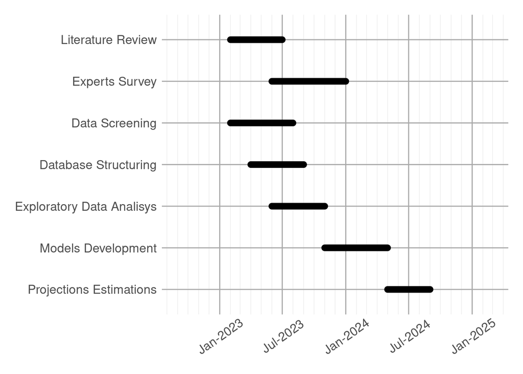

## References

Bowman, Maria S. 2016. “Impact of Foot-and-Mouth Disease Status on Deforestation in Brazilian Amazon and Cerrado Municipalities Between 2000 and 2010.” *Journal of Environmental Economics and Management* 75 (January). https://doi.org/10.1016/j.jeem.2015.08.003.

Cattaneo, Andrea. 2001. “Deforestation in the Brazilian Amazon: Comparing the Impacts of Macroeconomic Shocks, Land Tenure, and Technological Change.” *Land Economics* 77 (2). https://doi.org/10.2307/3147091.

Cavalcante, R. B. L., P. R. M. Pontes, P. W. M. Souza-Filho, and E. B. Souza. 2019. “Opposite Effects of Climate and Land Use Changes on the Annual Water Balance in the Amazon Arc of Deforestation.” *Water Resources Research* 55 (4). https://doi.org/10.1029/2019wr025083.

Dias, Fabiane Pereira Machado, Wilson Mozena Leandro, Paulo Marçal Fernandes, and Francisco Alisson da Silva Xavier. 2022. “Impact of Short-Term Land-Use Change on Soil Organic Carbon Dynamics in Transitional Agro-Ecosystems: A Case Study in the Brazilian Cerrado.” *Carbon Management* 13 (1). https://doi.org/10.1080/17583004.2022.2074313.

Gestich, Carla C., Víctor Arroyo-Rodríguez, Bruno H. Saranholi, Rogério G. T. da Cunha, Eleonore Z. F. Setz, and Milton C. Ribeiro. 2021. “Forest Loss and Fragmentation Can Promote the Crowding Effect in a Forest-Specialist Primate.” *Landscape Ecology* 37 (1). https://doi.org/10.1007/s10980-021-01336-1.

Hargrave, Jorge, and Krisztina Kis-Katos. 2012. “Economic Causes of Deforestation in the Brazilian Amazon: A Panel Data Analysis for the 2000s.” *Environmental and Resource Economics* 54 (4). https://doi.org/10.1007/s10640-012-9610-2.

Jusys, Tomas. 2016. “Fundamental Causes and Spatial Heterogeneity of Deforestation in Legal Amazon.” *Applied Geography* 75 (October). https://doi.org/10.1016/j.apgeog.2016.08.015.

Pfaff, Alexander, Juan Robalino, Diego Herrera, and Catalina Sandoval. 2015. “Protected Areas’ Impacts on Brazilian Amazon Deforestation: Examining Conservation - Development Interactions to Inform Planning.” *PLOS ONE* 10 (7). https://doi.org/10.1371/journal.pone.0129460.

Santos, Augusto Seabra, and Alexandre N. Almeida. 2018. “The Impact of Deforestation on Malaria Infections in the Brazilian Amazon.” *Ecological Economics* 154 (December). https://doi.org/10.1016/j.ecolecon.2018.08.005.

Silva, Richarde Marques da, Aricson Garcia Lopes, and Celso Augusto Guimarães Santos. 2023. “Deforestation and Fires in the Brazilian Amazon from 2001 to 2020: Impacts on Rainfall Variability and Land Surface Temperature.” *Journal of Environmental Management* 326 (January). https://doi.org/10.1016/j.jenvman.2022.116664.

## Reuse

CC BY-NC-ND 4.0